# Project-RW

### Red Wine Quality Analysis by R

```
##  [1] "X"                    "fixed.acidity"        "volatile.acidity"
##  [4] "citric.acid"          "residual.sugar"       "chlorides"
##  [7] "free.sulfur.dioxide"  "total.sulfur.dioxide" "density"
## [10] "pH"                   "sulphates"            "alcohol"
## [13] "quality"
```

```
## 'data.frame':    1599 obs. of  13 variables:
##  $ X                   : int  1 2 3 4 5 6 7 8 9 10 ...
##  $ fixed.acidity       : num  7.4 7.8 7.8 11.2 7.4 7.4 7.9 7.3 7.8 7.5 ...
##  $ volatile.acidity    : num  0.7 0.88 0.76 0.28 0.7 0.66 0.6 0.65 0.58 0.5 ...
##  $ citric.acid         : num  0 0 0.04 0.56 0 0 0.06 0 0.02 0.36 ...
##  $ residual.sugar      : num  1.9 2.6 2.3 1.9 1.9 1.8 1.6 1.2 2 6.1 ...
##  $ chlorides           : num  0.076 0.098 0.092 0.075 0.076 0.075 0.069 0.065 0.073 0.071 ...
##  $ free.sulfur.dioxide : num  11 25 15 17 11 13 15 15 9 17 ...
##  $ total.sulfur.dioxide: num  34 67 54 60 34 40 59 21 18 102 ...
##  $ density             : num  0.998 0.997 0.997 0.998 0.998 ...
##  $ pH                  : num  3.51 3.2 3.26 3.16 3.51 3.51 3.3 3.39 3.36 3.35 ...
##  $ sulphates           : num  0.56 0.68 0.65 0.58 0.56 0.56 0.46 0.47 0.57 0.8 ...
##  $ alcohol             : num  9.4 9.8 9.8 9.8 9.4 9.4 9.4 10 9.5 10.5 ...
##  $ quality             : int  5 5 5 6 5 5 5 7 7 5 ...
```

### Summary of Dataframe

```
## 'data.frame':    1599 obs. of  14 variables:
##  $ X                   : int  1 2 3 4 5 6 7 8 9 10 ...
##  $ fixed.acidity       : num  7.4 7.8 7.8 11.2 7.4 7.4 7.9 7.3 7.8 7.5 ...
##  $ volatile.acidity    : num  0.7 0.88 0.76 0.28 0.7 0.66 0.6 0.65 0.58 0.5 ...
##  $ citric.acid         : num  0 0 0.04 0.56 0 0 0.06 0 0.02 0.36 ...
##  $ residual.sugar      : num  1.9 2.6 2.3 1.9 1.9 1.8 1.6 1.2 2 6.1 ...
##  $ chlorides           : num  0.076 0.098 0.092 0.075 0.076 0.075 0.069 0.065 0.073 0.071 ...
##  $ free.sulfur.dioxide : num  11 25 15 17 11 13 15 15 9 17 ...
##  $ total.sulfur.dioxide: num  34 67 54 60 34 40 59 21 18 102 ...
##  $ density             : num  0.998 0.997 0.997 0.998 0.998 ...
##  $ pH                  : num  3.51 3.2 3.26 3.16 3.51 3.51 3.3 3.39 3.36 3.35 ...
##  $ sulphates           : num  0.56 0.68 0.65 0.58 0.56 0.56 0.46 0.47 0.57 0.8 ...
##  $ alcohol             : num  9.4 9.8 9.8 9.8 9.4 9.4 9.4 10 9.5 10.5 ...
##  $ quality             : Ord.factor w/ 6 levels "3"<"4"<"5"<"6"<..: 3 3 3 4 3 3 3 5 5 3 ...
##  $ rating              : Ord.factor w/ 3 levels "bad"<"average"<..: 2 2 2 2 2 2 2 3 3 2 ...
```

```
##        X          fixed.acidity   volatile.acidity  citric.acid
##  Min.   :   1.0   Min.   : 4.60   Min.   :0.1200   Min.   :0.000
##  1st Qu.: 400.5   1st Qu.: 7.10   1st Qu.:0.3900   1st Qu.:0.090
##  Median : 800.0   Median : 7.90   Median :0.5200   Median :0.260
##  Mean   : 800.0   Mean   : 8.32   Mean   :0.5278   Mean   :0.271
##  3rd Qu.:1199.5   3rd Qu.: 9.20   3rd Qu.:0.6400   3rd Qu.:0.420
##  Max.   :1599.0   Max.   :15.90   Max.   :1.5800   Max.   :1.000
##  residual.sugar     chlorides       free.sulfur.dioxide
##  Min.   : 0.900   Min.   :0.01200   Min.   : 1.00
##  1st Qu.: 1.900   1st Qu.:0.07000   1st Qu.: 7.00
##  Median : 2.200   Median :0.07900   Median :14.00
##  Mean   : 2.539   Mean   :0.08747   Mean   :15.87
##  3rd Qu.: 2.600   3rd Qu.:0.09000   3rd Qu.:21.00
##  Max.   :15.500   Max.   :0.61100   Max.   :72.00
##  total.sulfur.dioxide    density             pH          sulphates
##  Min.   :  6.00       Min.   :0.9901   Min.   :2.740   Min.   :0.3300
##  1st Qu.: 22.00       1st Qu.:0.9956   1st Qu.:3.210   1st Qu.:0.5500
##  Median : 38.00       Median :0.9968   Median :3.310   Median :0.6200
##  Mean   : 46.47       Mean   :0.9967   Mean   :3.311   Mean   :0.6581
##  3rd Qu.: 62.00       3rd Qu.:0.9978   3rd Qu.:3.400   3rd Qu.:0.7300
##  Max.   :289.00       Max.   :1.0037   Max.   :4.010   Max.   :2.0000
##     alcohol      quality     rating
##  Min.   : 8.40   3: 10   bad    :  63
##  1st Qu.: 9.50   4: 53   average:1319
##  Median :10.20   5:681   good   : 217
##  Mean   :10.42   6:638
##  3rd Qu.:11.10   7:199
##  Max.   :14.90   8: 18
```

### Univariate Plots

First i want to know distribution of indivisual variables.

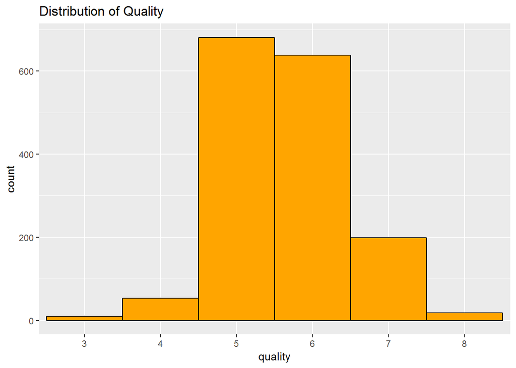

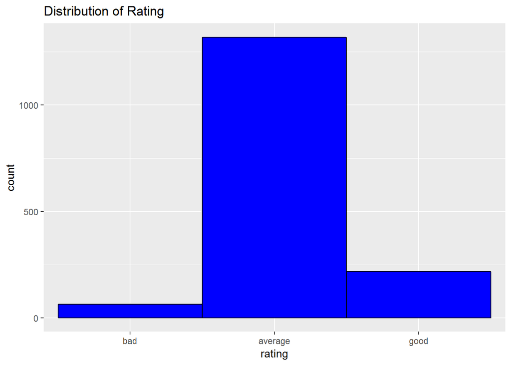

From the above we came to know that most of the wines in the dataset are average quality wines.

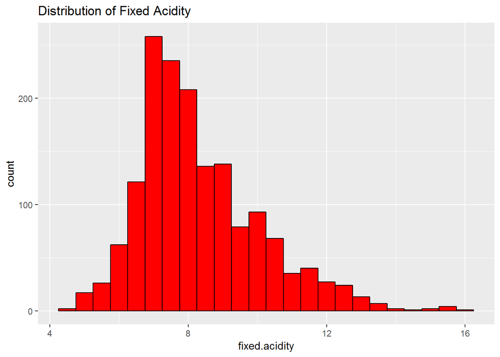

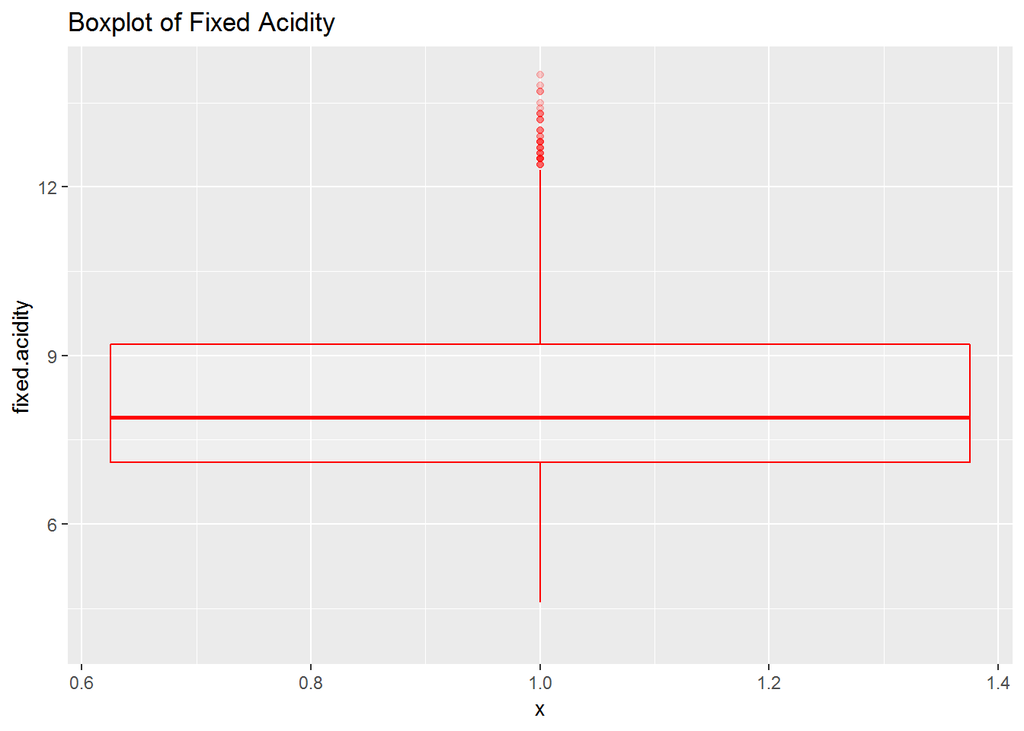

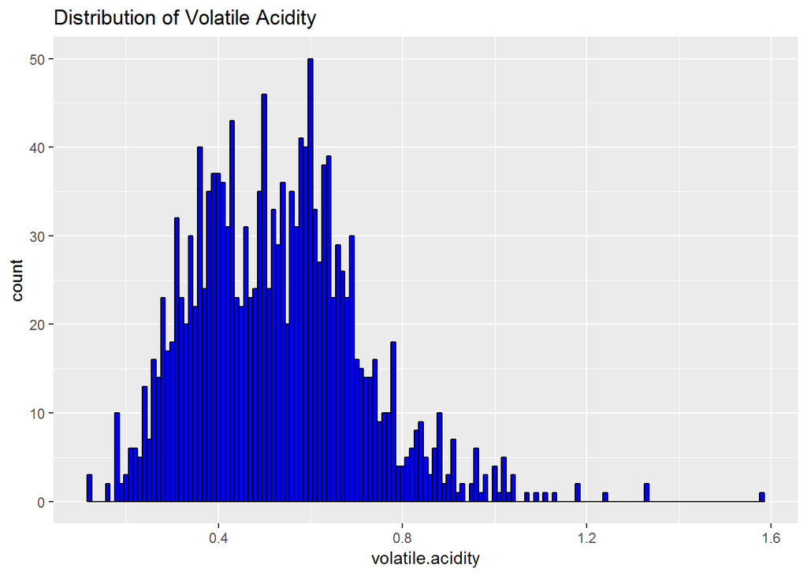

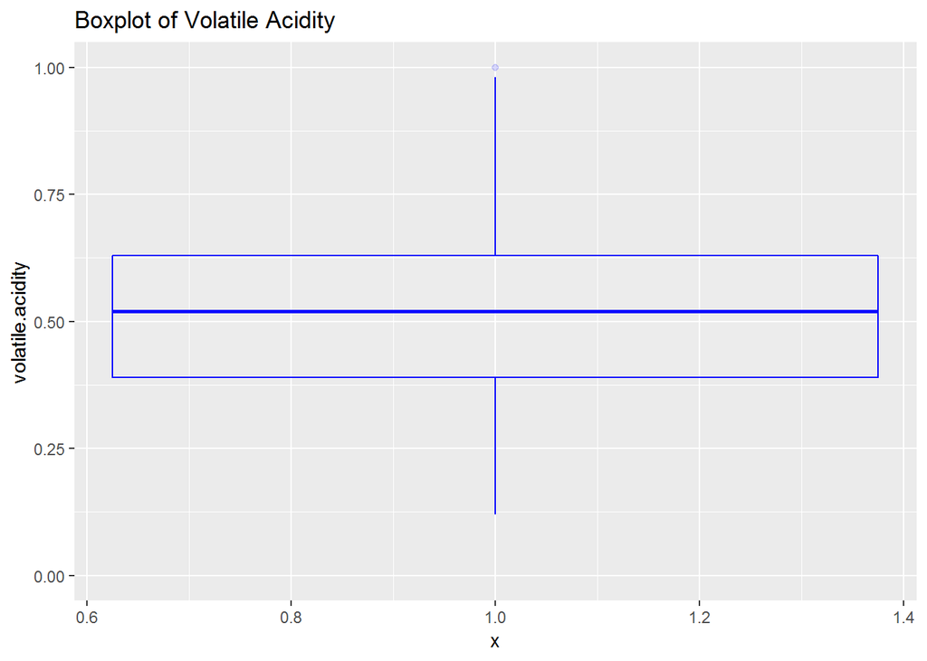

The distribution of volatile.acidity is bimodal normal and peak is in between 0.4 and 0.6 .

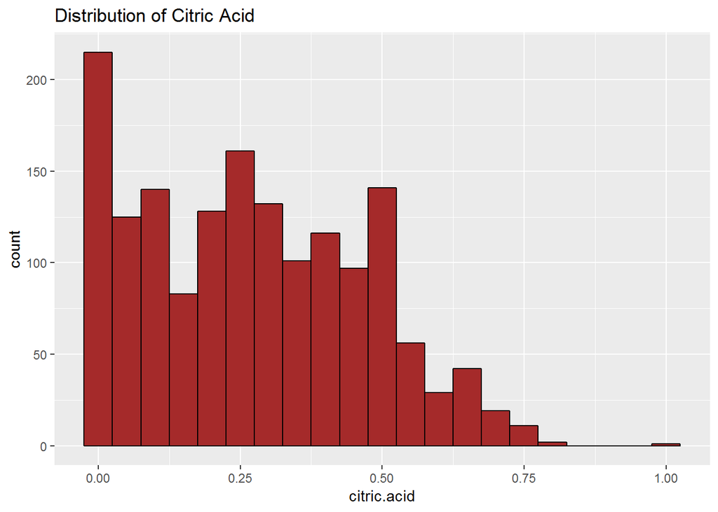

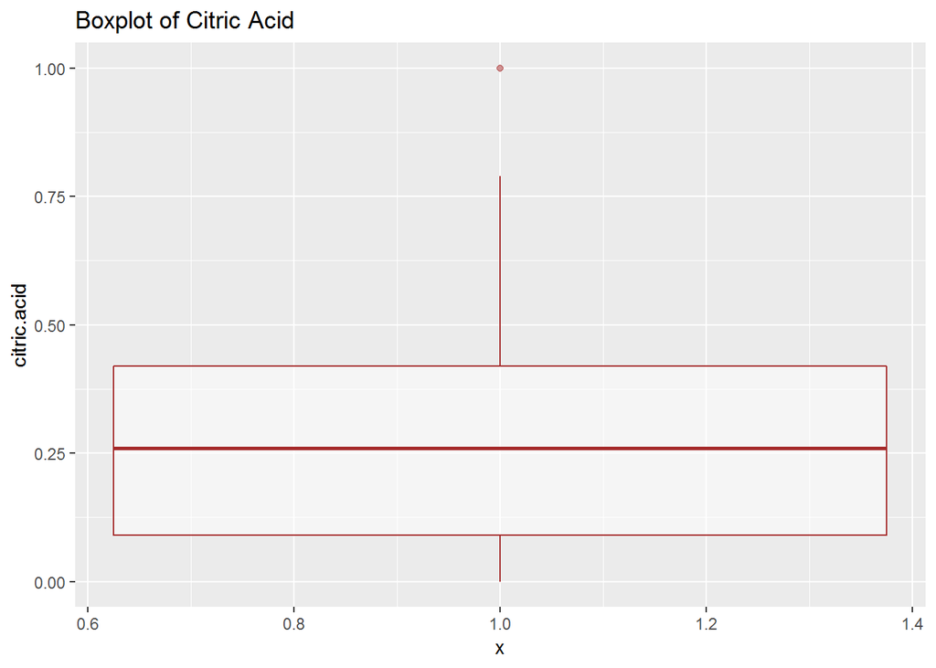

The distribution is almost look like rectangular.

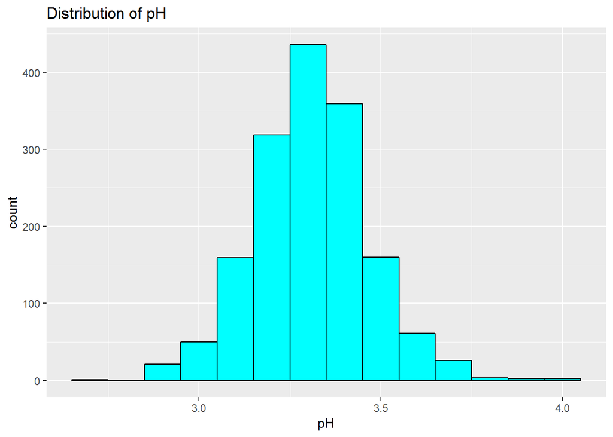

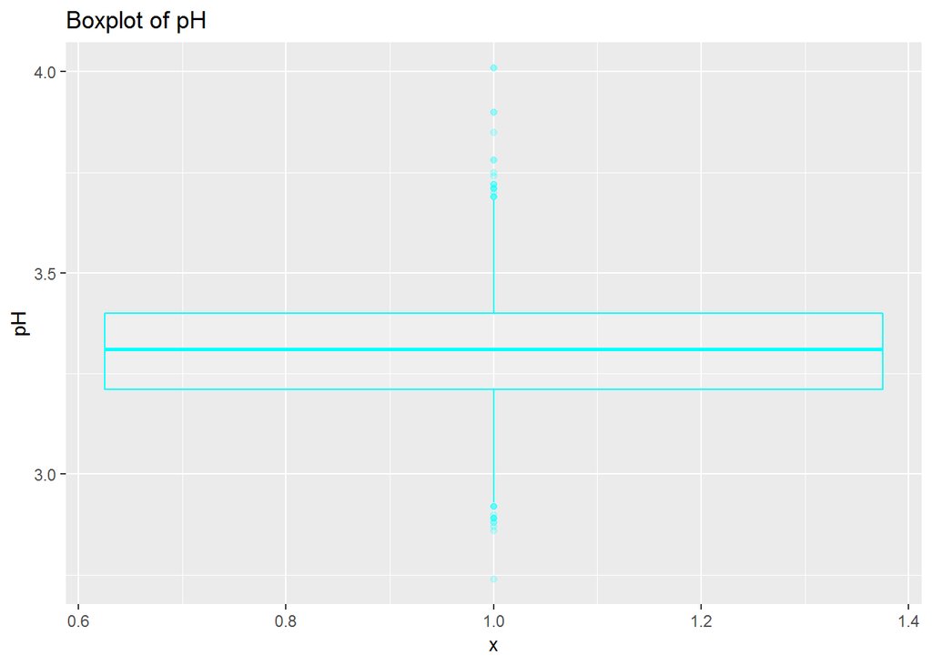

The pH is very normaly Distributed.

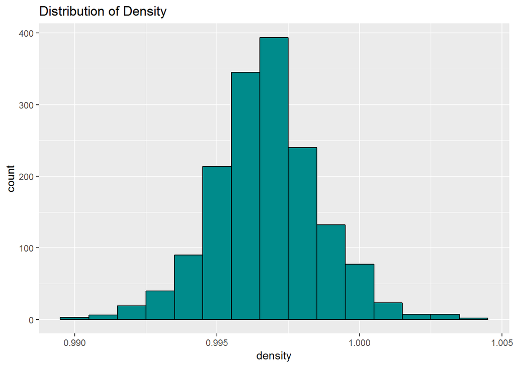

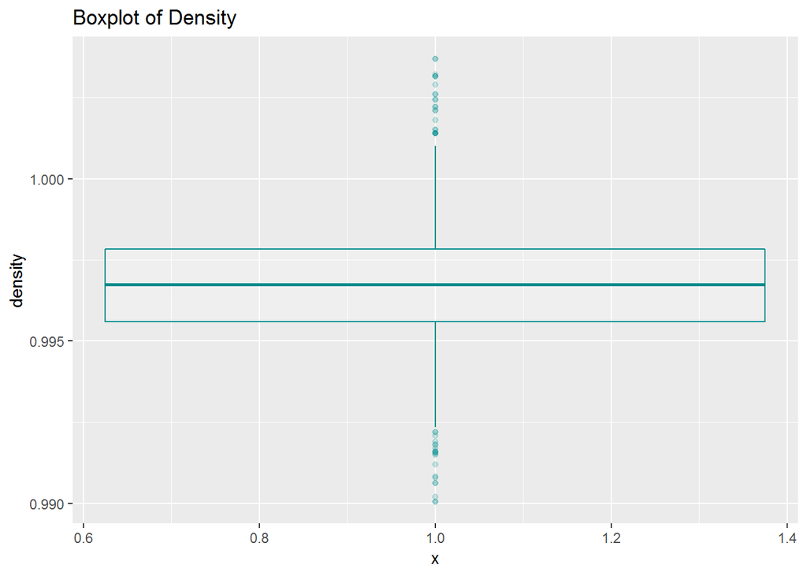

The density also normaly distributed.

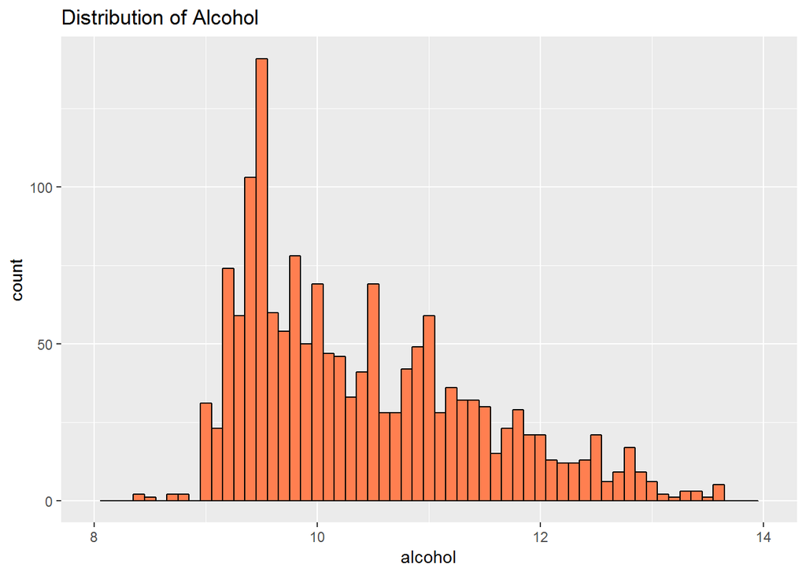

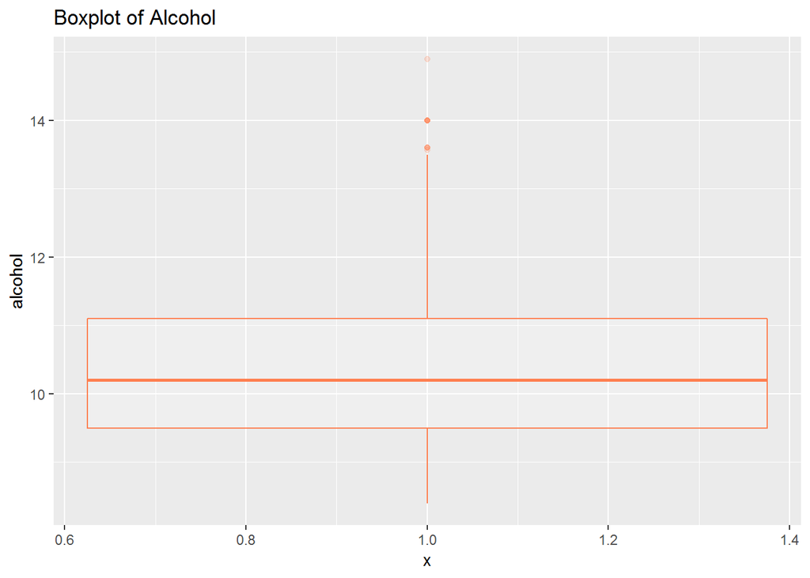

Alcohol also positive skewed distibution.

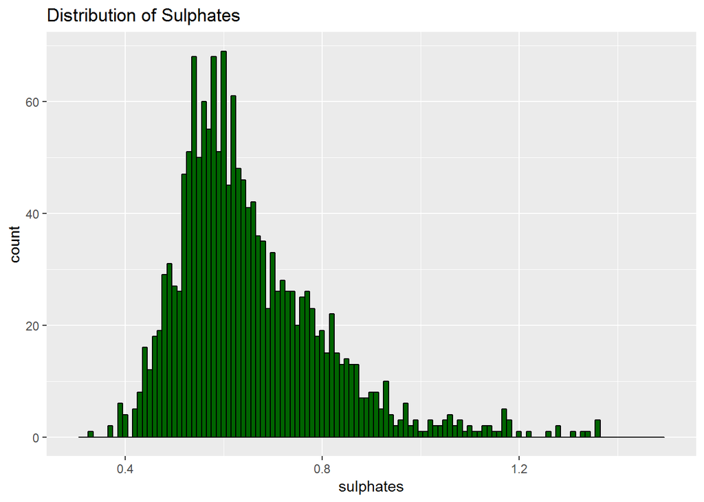

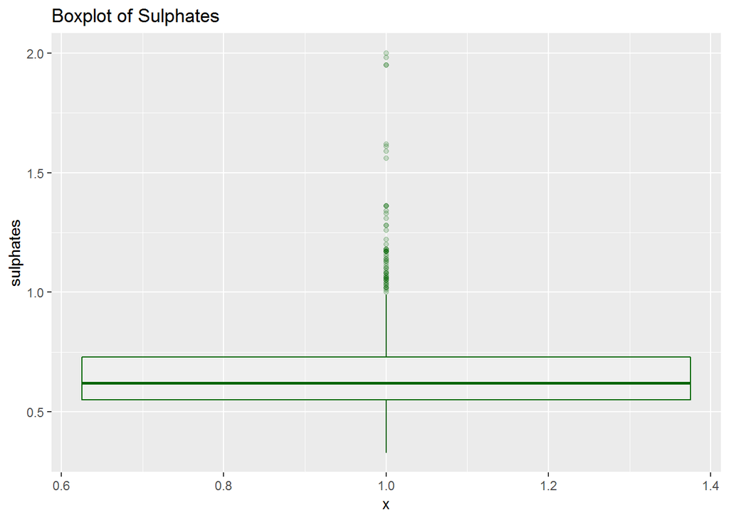

Sulphates have long tailed postive distrubtion.

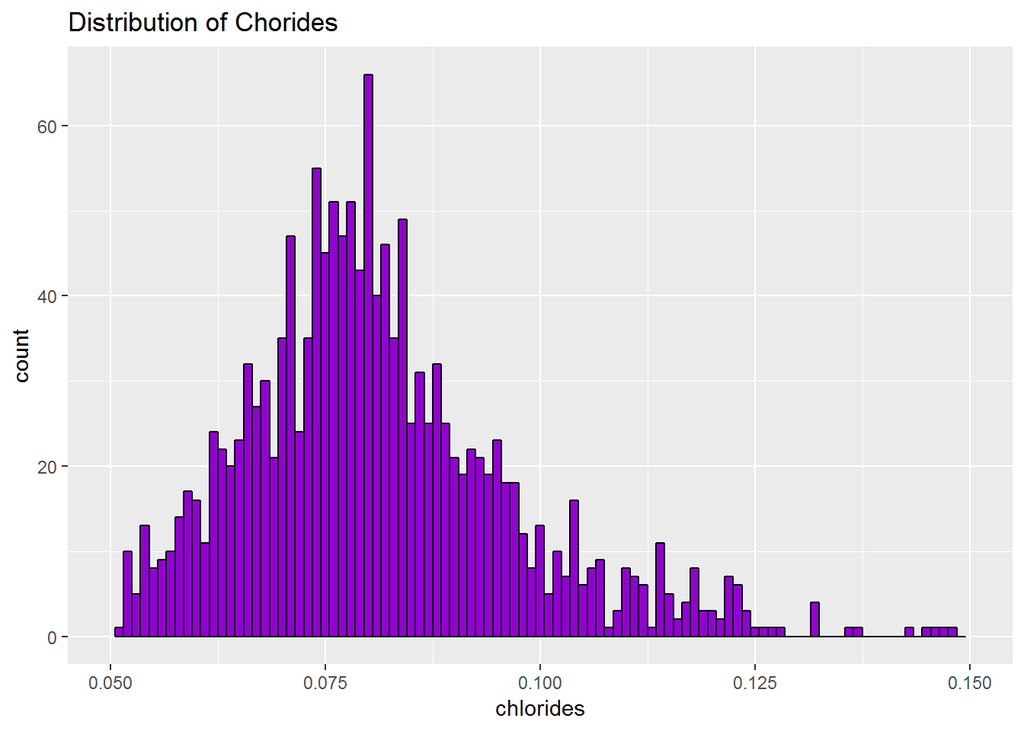

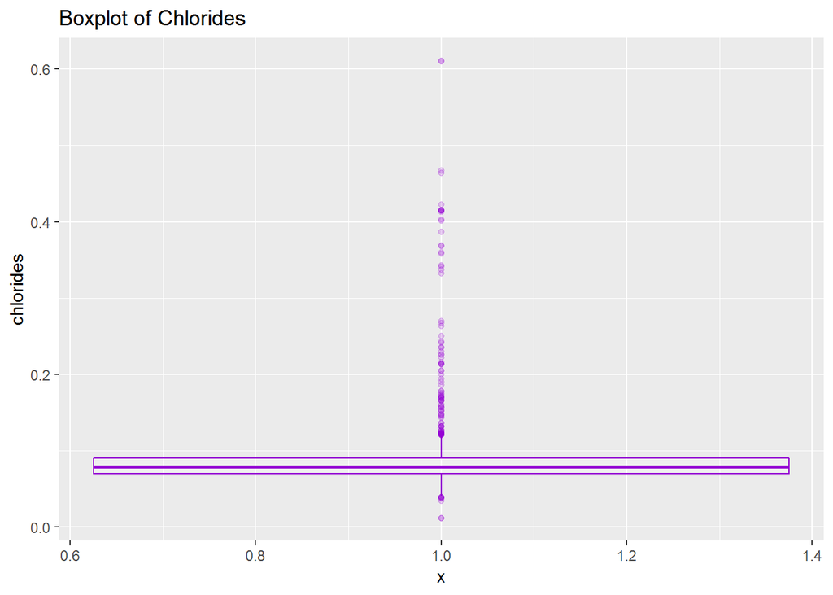

After rearranging the extreme outliers it is look like positive distribution.

### Univariate Analysis

#### What is the structure of your dataset?

The following observations are distributions of variables :

- Quality has most values concentrated in the categories 5, 6 and 7. Only a small proportion is in the categories [3, 4] and [8, 9] and none in the categories [1, 2] and 10.
- Fixed acidity, volatile acidity and citric acid have outliers. If those outliers are eliminated distribution of the variables may be taken to be symmetric.
- Some of the variables, e.g . free sulphur dioxide, density, have a few outliers but these are very different from the rest.
- Mostly outliers are on the larger side.
- Alcohol has an irregular shaped distribution but it does not have pronounced outliers.

#### What is/are the main feature(s) of interest in your dataset?

The main features in the data set are alcohol, quality . I’d like to find which features are best for predicting quality of wine. I think along with alcohol, quantity and acidity (both fixed and volatile) might be used for predictive modeling to determine quality of wine.

#### What other features in the dataset do you think will help support your investigation into your feature(s) of interest?

Sulphates, Acidity (both fixed and volatile), density, chlorides , pH are likely to contribute to quality of wine.

#### Did you create any new variables from existing variables in the dataset?

Yes, rating is the variable added to the dataset which is divided into 3 groups like bad , average , good for know the rating of wines.Most of wines in the data set are average wines.

#### Of the features you investigated, were there any unusual distributions? Did you perform any operations on the data to tidy, adjust, or change the form of the data? If so, why did you do this?

According to all the above plots, there are some outliers in some of the features like sulphates , acidity (fixed and volatile). Also the distribution for Volatile acidity apears to be bimodal normal distribution.

### Bivariate Plots Section

#### Pearson correlation

Let’s investigate as well the correlation between the variables using cor function for Pearson correlation.

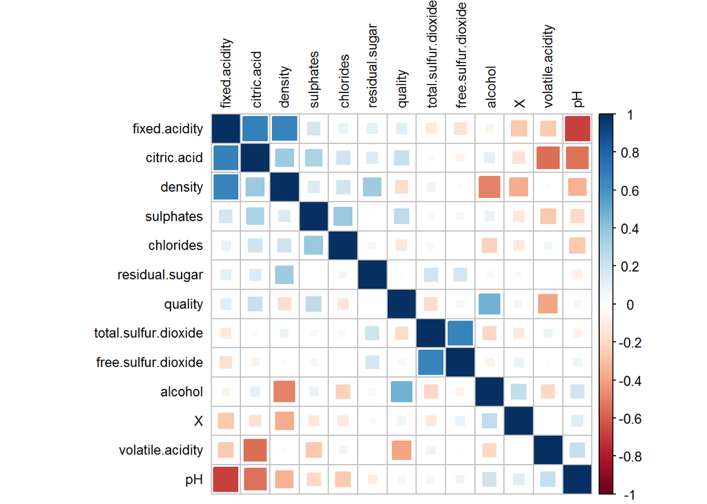

- Highly correlated variables:
1. total.sulfur.dioxide with free.sulfur.dioxide;
2. fixed.acidity with density and citric.acid;
- The variables are relatively correlated:
1. alcohol with quality (this might be a candidate for drop, since might be a leak);
- Relativelly highly inverse correlated variables:

1)fixed.acidity with pH;

- The following dimmensions are relatively inverse correlated:

1)citric.acid with pH and volatile.acidity;

> plot for Alcohol and Quality:

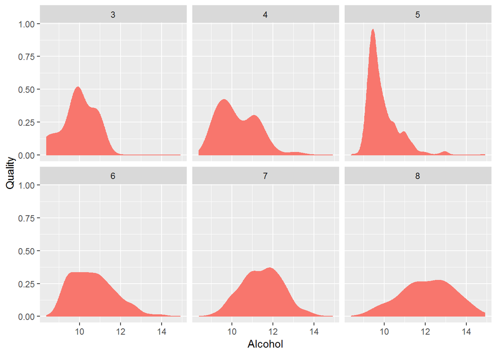

```
## $title
## [1] "Alcohol vS quality"
##
## $subtitle
## NULL
##
## attr(,"class")
## [1] "labels"
```

The plot shows that higher density readings for the Quality levels for 5 and 3.Level 8 is the low density.All levels have normaly skewed.

> correlation of volatile acidity and quality :

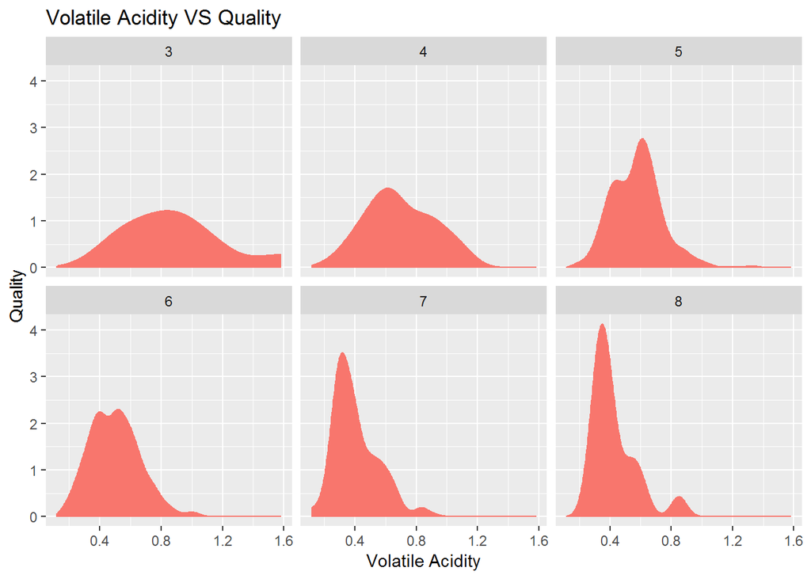

> correlation of Free sulfur.dioxide and Total sulfur.dioxide:

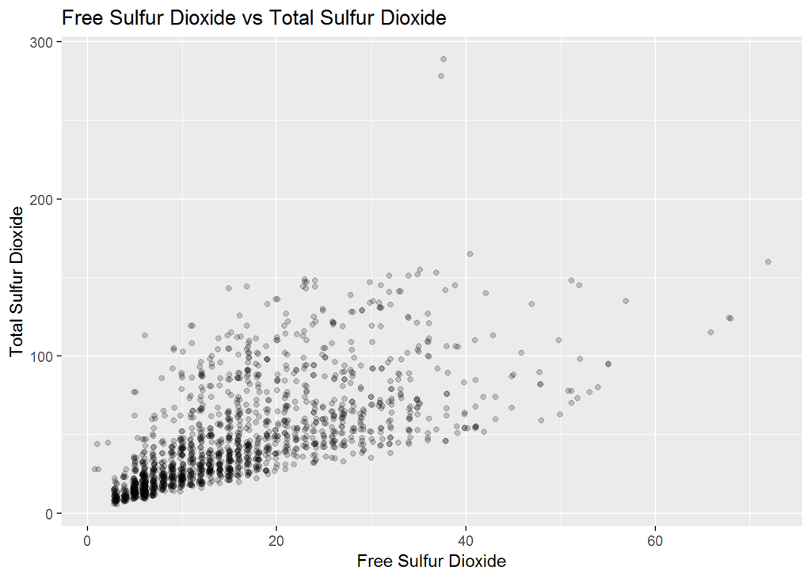

It is a positive corelation between Free Sulfur Dioxide and Total Sulfur Dioxide.

> Lets plot for residual sugar and quality:

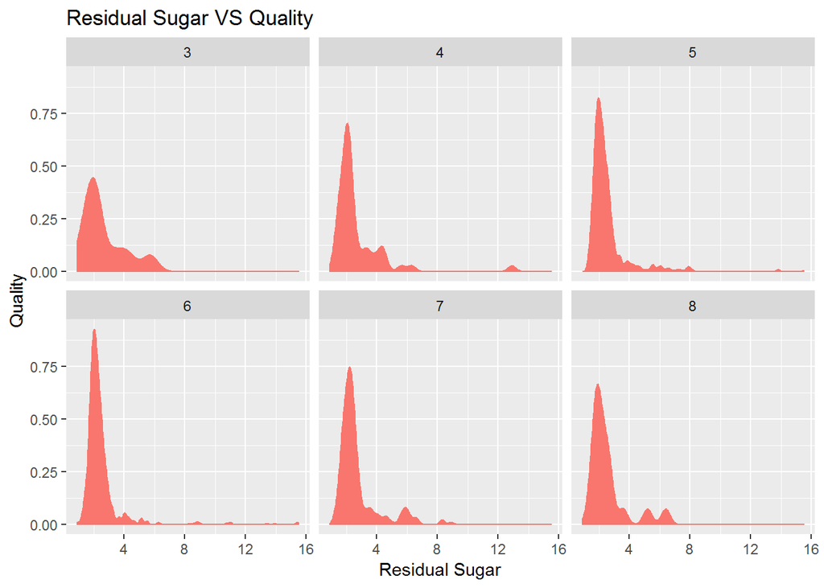

Except for quality 3, other quality rating shows higher density of residual sugar. But no pattern is observed which can help us to predict the quality of wine from residual sugar. So this is not a good attribute used to classify quality of wine.

> Lets plot relation between fixed acidity and citric acid:

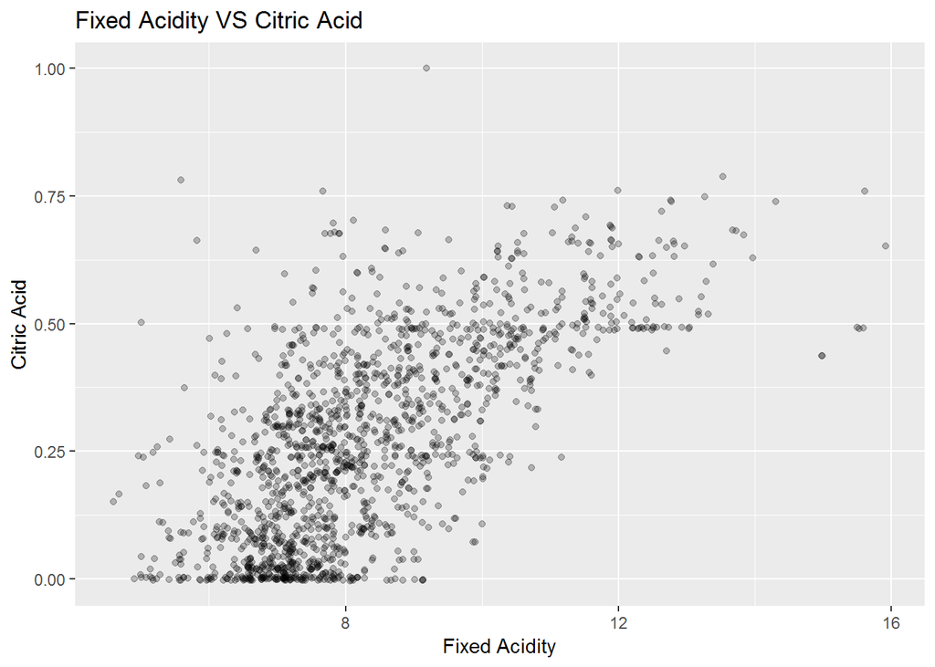

Since citric acid and fixed acid have the positive relation, thus exhibiting a significant positive correlation.

> Relation between fixed.acidity and density :

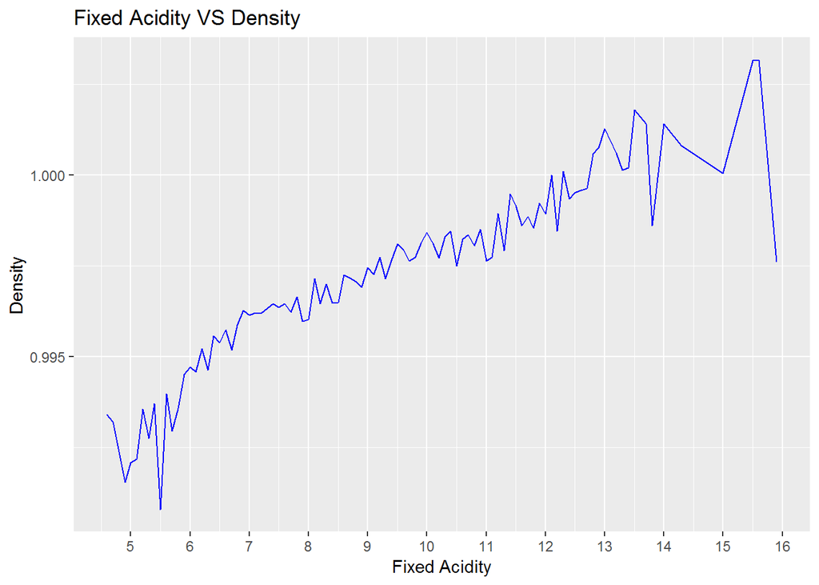

Both have positive corelation. Also from range 6 - 12.5, we observe very less deviation from mean while in other values, it shows significant deviation from mean.

> plot for fixed acidity and pH:

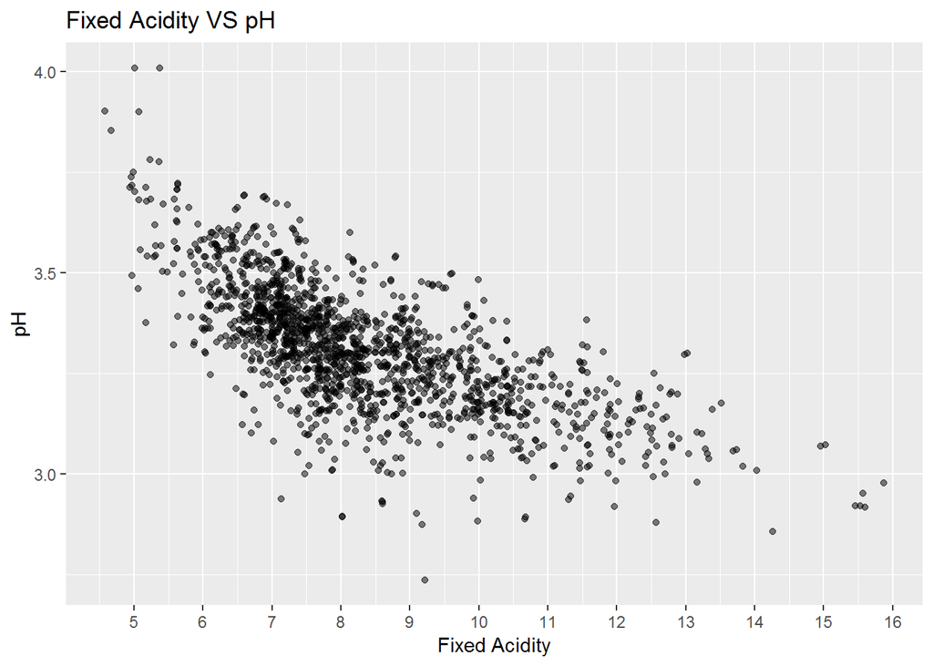

The relation is negatively related between acidity and pH levels and most of the data is clustered around range 5 - 14.

> plot for density and alcohol:

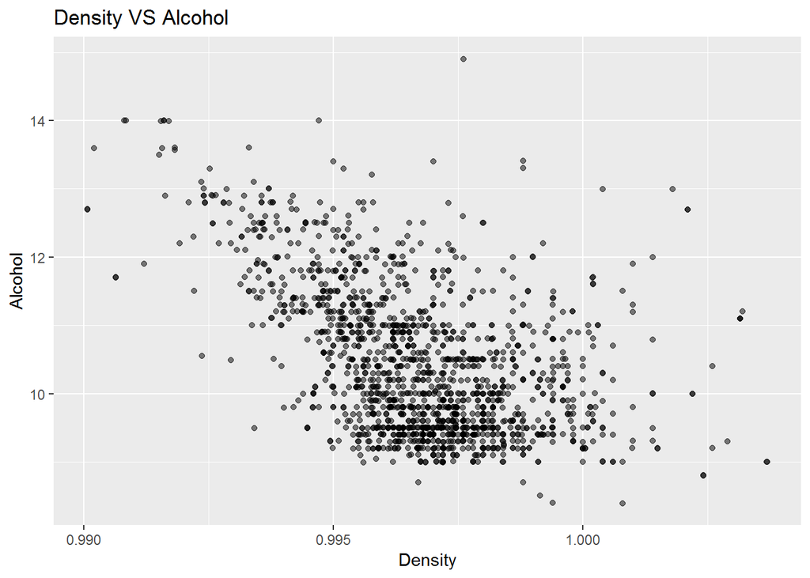

It is negatively corelated and most of the data clustered at the middle.

> Plot for ResidualSugar and Rating:

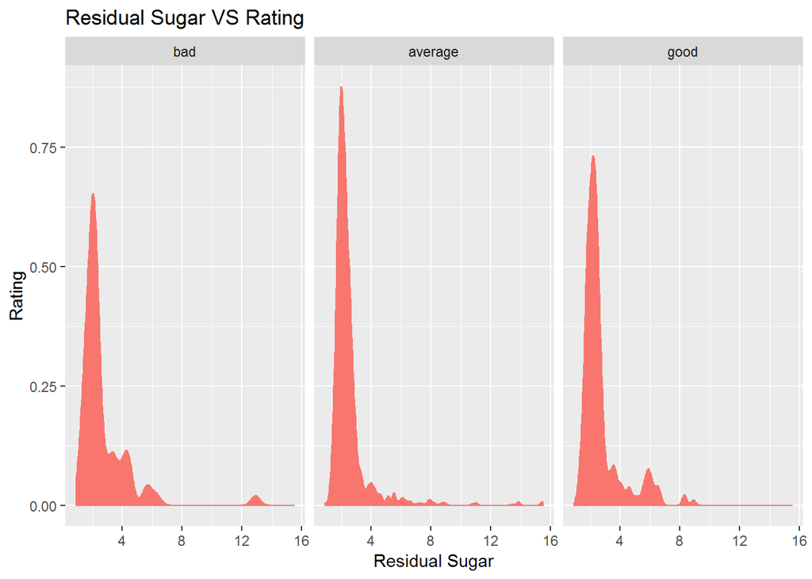

The average rating wines are having high density and from the above we can came to know that all wines having high density rating at point 2.

# Bivariate Analysis

### What was the strongest relationship you found?

Strong relationships that I observed are:

- Positively Related :
  - Fixed acidity - density
  - Free Sulfur Dioxide - Total Sulfur Dioxide
  - Alcohol - quality
- Negatively Related:
  - Fixed acidity - pH
  - Volatile acidity and Citric Acid

# Multivariate Plots Section

> Plot for Alcohol_VS_Citric_Acid_VS_Quality:

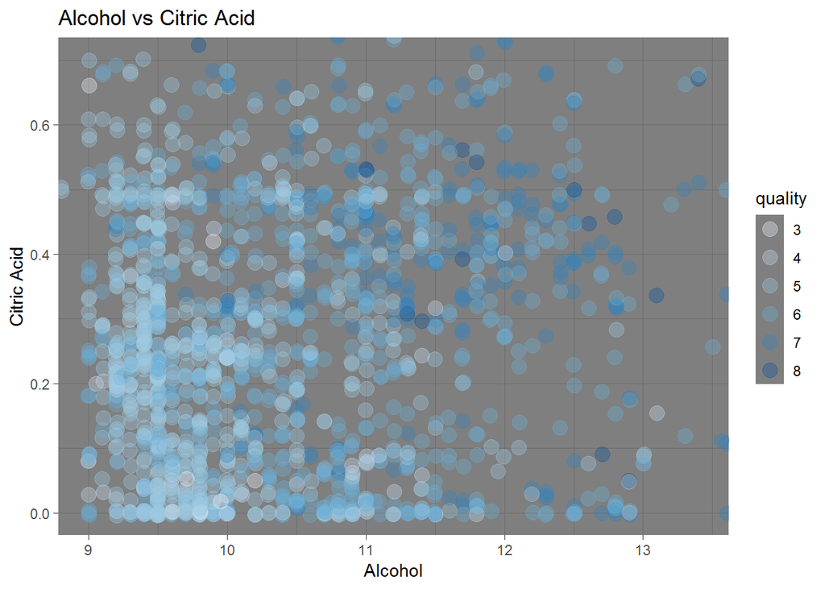

```
## # A tibble: 6 x 7
## # Groups:   quality [?]
##   quality rating  mean_A median_A variance_A std_A     n
##   <ord>   <ord>    <dbl>    <dbl>      <dbl> <dbl> <int>
## 1 3       bad       9.96     9.93      0.669 0.818    10
## 2 4       bad      10.3     10         0.874 0.935    53
## 3 5       average   9.90     9.7       0.542 0.737   681
## 4 6       average  10.6     10.5       1.10  1.05    638
## 5 7       good     11.5     11.5       0.925 0.962   199
## 6 8       good     12.1     12.2       1.50  1.22     18
```

Something interesting emerge from this chart which is good wines concentrate when citric acid is more than 0.3 and alcohol is more than 10.5. That is, when we have certain levels of both then we have a more high quality scores.

> Plot for VolatileAcidity_VS_Citric_Acid_VS_Quality:

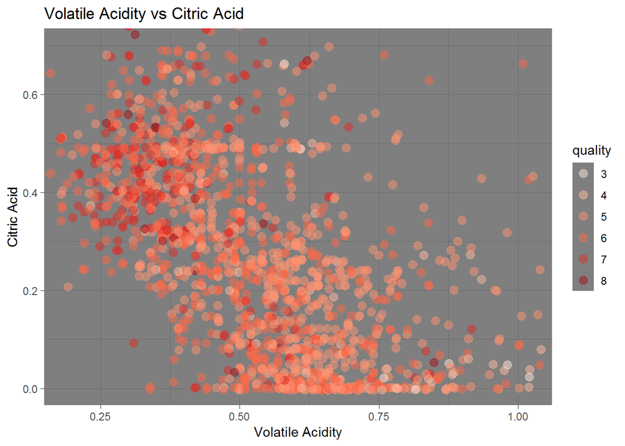

```
## # A tibble: 6 x 7
## # Groups:   quality [?]
##   quality rating  mean_VA median_VA variance_VA std_VA     n
##   <ord>   <ord>     <dbl>     <dbl>       <dbl>  <dbl> <int>
## 1 3       bad       0.884     0.845      0.110   0.331    10
## 2 4       bad       0.694     0.67       0.0484  0.220    53
## 3 5       average   0.577     0.580      0.0272  0.165   681
## 4 6       average   0.497     0.49       0.0259  0.161   638
## 5 7       good      0.404     0.37       0.0211  0.145   199
## 6 8       good      0.423     0.37       0.0210  0.145    18
```

The graph shows us that good wines constitue citric acid above 0.27 g/dm<sup>3</sup> and volatile acidity below 0.5 g/dm<sup>3</sup>.

> Plot for FixedAcidity_VS_Density_VS_Quality:

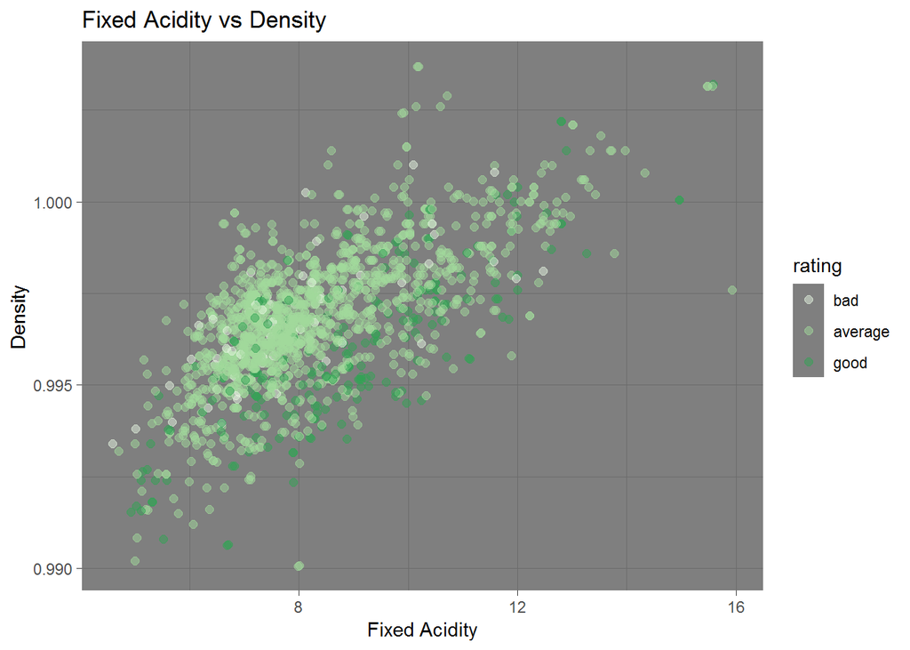

```
## # A tibble: 6 x 7
## # Groups:   quality [?]
##   quality rating  mean_FA median_FA variance_FA std_FA     n
##   <ord>   <ord>     <dbl>     <dbl>       <dbl>  <dbl> <int>
## 1 3       bad        8.36      7.5         3.14   1.77    10
## 2 4       bad        7.78      7.5         2.65   1.63    53
## 3 5       average    8.17      7.8         2.45   1.56   681
## 4 6       average    8.35      7.9         3.23   1.80   638
## 5 7       good       8.87      8.8         3.97   1.99   199
## 6 8       good       8.57      8.25        4.49   2.12    18
```

Most of Wines rating lies within 0.995 g / dm<sup>3</sup>, 1.000 g / dm<sup>3</sup> range for Density and 6 g / dm<sup>3</sup>, 9 g / dm<sup>3</sup> for Fixed Acidity. Average wines seems to be distributed across the plot.

> Plot for Density_vs_Alcohol_vs_Quality:

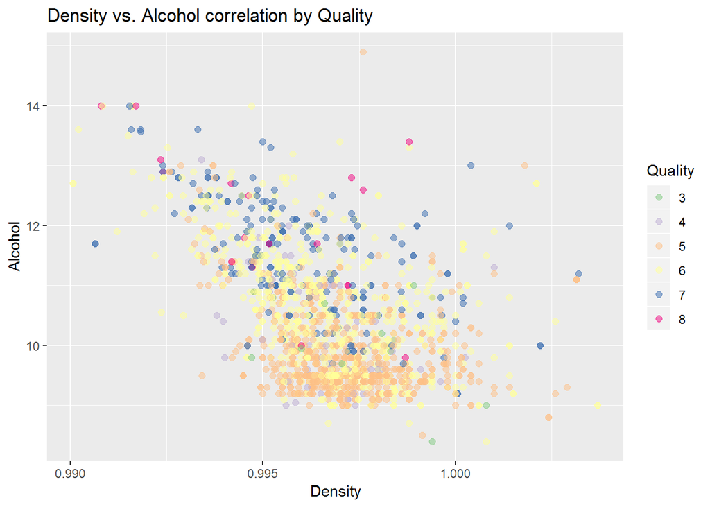

Negative correlation is observed. Most of wine samples with quality 5 and 6 seems to be distributed with alcohol content less 11% by volume, while samples with quality 7 above 11% alcohol by volume.